# PCA

### Importo las librerías

```python
import pandas as pd
import numpy as np
import sklearn
from sklearn.pipeline import Pipeline
from sklearn import metrics
# conda install category_encoders
import category_encoders as ce
from sklearn.preprocessing import OneHotEncoder
from numpy.linalg import eigh
import matplotlib.pyplot as plt
import seaborn as sns
from sklearn.decomposition import PCA
import seaborn as sns
import matplotlib.pyplot as plt
from sklearn.preprocessing import StandardScaler
from sklearn.feature_selection import SelectFromModel
from sklearn.linear_model import LogisticRegression
from sklearn.ensemble import GradientBoostingClassifier
from sklearn import metrics
from sklearn.discriminant_analysis import LinearDiscriminantAnalysis as LDA
```

## Lectura del dataset: train y test

```python
pd_loan_train = pd.read_csv("./data_preprocessing/train_pd_data_preprocessing_missing_outlier.csv")\
                  .set_index(['id', 'url', 'zip_code'])
pd_loan_test = pd.read_csv("./data_preprocessing/test_pd_data_preprocessing_missing_outlier.csv")\
                  .set_index(['id', 'url', 'zip_code'])
```

```python
pd_loan_train.columns
```

```
Index(['grade', 'home_ownership', 'verification_status', 'initial_list_status',
       'purpose', 'addr_state', 'application_type', 'loan_status',
       'total_acc_input', 'fico_range_high_input',
       'mo_sin_old_rev_tl_op_input', 'pub_rec_bankruptcies_input',
       'sub_grade_input', 'mths_since_last_record_input', 'loan_amnt_input',
       'earliest_cr_line_month_input', 'mo_sin_old_il_acct_input',
       'installment_input', 'earliest_cr_line_year_input', 'term_input',
       'mths_since_recent_revol_delinq_input', 'mths_since_last_delinq_input',
       'fico_range_low_input', 'mths_since_last_major_derog_input',
       'revol_util_input', 'mths_since_recent_bc_dlq_input', 'dti_input',
       'emp_length_input', 'open_acc_input', 'pub_rec_input',
       'annual_inc_input', 'mort_acc_input', 'int_rate_input'],
      dtype='object')
```

## Codificación de la variable objetivo y del resto de variables categoricas

1: Charged off

0: Fully Paid

```python
print(pd_loan_train['loan_status'].value_counts())
pd_loan_train['loan_status'] = pd_loan_train['loan_status']\
                                .map({'Fully Paid': 0, 'Charged Off': 1}).astype(int)

pd_loan_test['loan_status'] = pd_loan_test['loan_status']\
                                .map({'Fully Paid': 0, 'Charged Off': 1}).astype(int)
```

```
Fully Paid     276416
Charged Off     77637
Name: loan_status, dtype: int64
```

```python
X_train = pd_loan_train.drop('loan_status',axis=1)
X_test = pd_loan_test.drop('loan_status',axis=1)
y_train = pd_loan_train['loan_status']
y_test = pd_loan_test['loan_status']
```

Por ejemplo, elijo codificarlas con one-hot-encoding todas. Se podría elegir codificar algunas de una forma y otras de otra. Por ejemplo, variables con pocas categorías con one hot encoding y variables con más categorias con TargetEncoding

```python
list_columns_cat = list(X_train.select_dtypes("object", "category").columns)
list_other = list(set(X_train.columns)-set(list_columns_cat))
ohe = ce.OneHotEncoder(cols=list_columns_cat)
model = ohe.fit(X_train, y_train)
```

```python
X_train_t = model.transform(X_train, y_train)
X_test_t = model.transform(X_test, y_test)
len(list(X_train_t.columns))
```

```
108
```

Es posible que para la variable addr_state vaya mejor un TargetEncoding o un Catboost encoder. Se pueden probar diferentes posibilidades

## Escalado de las variables

En algunos algoritmos no es necesario estandarizar variables, aunque no pasa nada si se hace. Probad

https://scikit-learn.org/stable/modules/generated/sklearn.preprocessing.StandardScaler.html

```python
scaler = StandardScaler()
model_scaled = scaler.fit(X_train_t)
X_train_scaled = pd.DataFrame(scaler.transform(X_train_t), columns=X_train_t.columns, index=X_train_t.index)
X_test_scaled = pd.DataFrame(scaler.transform(X_test_t), columns=X_test_t.columns, index=X_test.index)
```

## Métodos de elección de las variables más importantes

https://scikit-learn.org/stable/modules/generated/sklearn.feature_selection.SelectFromModel.html

## 1. SelectFromModel

SelectFromModel es una función que puede utilizarse junto con cualquier estimador que asigne importancia a cada variable a través de un atributo específico (como coef_, feature*importances*). Las características que se consideran "poco importantes", se eliminan. Si la importancia correspondiente de los valores de las características está por debajo del parámetro de umbral proporcionado. Aparte de especificar el umbral numéricamente, existen heurísticas incorporadas para encontrar un umbral utilizando un argumento de cadena. Las heurísticas disponibles son "media", "mediana" y múltiplos flotantes de éstas, como "0,1*media". En combinación con el criterio del umbral, se puede utilizar el parámetro max_features para establecer un límite en el número de características a seleccionar.

https://scikit-learn.org/stable/modules/feature_selection.html

El inconveniente de este método es que tú mismo tienes que elegir el threshold a partir del cual eliges las "n" primeras variables

### * Regresiones con regularización

Las estrategias de regularización incorporan penalizaciones en el ajuste por mínimos cuadrados ordinarios (OLS) con el objetivo de evitar overfitting, reducir varianza, atenuar el efecto de la correlación entre predictores y minimizar la influencia en el modelo de los predictores menos relevantes. Por lo general, aplicando regularización se consigue modelos con mayor poder predictivo (generalización).

Dado que estos métodos de regularización actúan sobre la magnitud de los coeficientes del modelo, todos deben de estár en la misma escala, por esta razón es necesario estandarizar o normalizar los predictores antes de entrenar el modelo.

### - Regularización Ridge

La regularización Ridge penaliza la suma de los coeficientes estimados elevados al cuadrado A esta penalización se le conoce como l2 y tiene el efecto de reducir de forma proporcional el valor de todos los coeficientes del modelo pero sin que estos lleguen a cero.

El grado de penalización está controlado por el hiperparámetro λ . Cuando λ=0 , la penalización es nula y el resultado es equivalente al de un modelo lineal por mínimos cuadrados ordinarios (OLS). A medida que λ aumenta, mayor es la penalización y menor el valor de los predictores.

```python
sel_ridge = SelectFromModel(LogisticRegression(C=1, penalty='l2'), threshold = 0.009)
sel_ridge.fit(X_train_scaled, y_train)
# Si aplicas transform(X_train_scaled, y_train) y transform(X_test_scaled, y_test), filtra las variables seleccionadas
```

```
SelectFromModel(estimator=LogisticRegression(C=1), threshold=0.009)
```

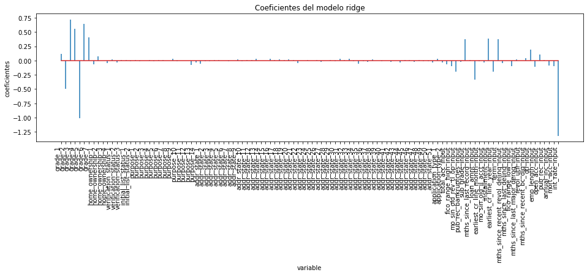

```python
# Coeficientes del modelo
# ==============================================================================
df_coeficientes = pd.DataFrame(
                        {'predictor': X_train_scaled.columns,
                         'coef': sel_ridge.estimator_.coef_.flatten()}
                  )

fig, ax = plt.subplots(figsize=(16, 3.84))
ax.stem(df_coeficientes.predictor, df_coeficientes.coef, markerfmt=' ')
plt.xticks(rotation=90, ha='right', size=10)
ax.set_xlabel('variable')
ax.set_ylabel('coeficientes')
ax.set_title('Coeficientes del modelo ridge');
```

```python
sel_ridge.get_support()
selected_feat = X_train_scaled.columns[sel_ridge.get_support()]
selected_feat
```

```
Index(['grade_1', 'grade_2', 'grade_3', 'grade_4', 'grade_5', 'grade_6',
       'grade_7', 'home_ownership_1', 'home_ownership_2', 'home_ownership_4',
       'verification_status_1', 'verification_status_2',
       'verification_status_3', 'purpose_5', 'purpose_6', 'purpose_9',
       'purpose_10', 'purpose_13', 'purpose_14', 'addr_state_1',
       'addr_state_2', 'addr_state_3', 'addr_state_4', 'addr_state_5',
       'addr_state_7', 'addr_state_9', 'addr_state_10', 'addr_state_11',
       'addr_state_13', 'addr_state_16', 'addr_state_18', 'addr_state_20',
       'addr_state_21', 'addr_state_22', 'addr_state_24', 'addr_state_26',
       'addr_state_27', 'addr_state_29', 'addr_state_30', 'addr_state_31',
       'addr_state_33', 'addr_state_34', 'addr_state_35', 'addr_state_36',
       'addr_state_37', 'addr_state_38', 'addr_state_42', 'addr_state_44',
       'addr_state_47', 'addr_state_48', 'addr_state_49', 'addr_state_50',
       'addr_state_51', 'application_type_1', 'application_type_2',
       'total_acc_input', 'fico_range_high_input',
       'mo_sin_old_rev_tl_op_input', 'pub_rec_bankruptcies_input',
       'sub_grade_input', 'mths_since_last_record_input', 'loan_amnt_input',
       'earliest_cr_line_month_input', 'mo_sin_old_il_acct_input',
       'installment_input', 'earliest_cr_line_year_input', 'term_input',
       'mths_since_recent_revol_delinq_input', 'fico_range_low_input',
       'mths_since_last_major_derog_input', 'mths_since_recent_bc_dlq_input',
       'dti_input', 'emp_length_input', 'open_acc_input', 'annual_inc_input',
       'mort_acc_input', 'int_rate_input'],
      dtype='object')
```

```python
print('total features: {}'.format((X_train_scaled.shape[1])))
print('selected features: {}'.format(len(selected_feat)))
```

```
total features: 108
selected features: 77
```

```python
X_train_scaled[selected_feat].shape
```

```
(354053, 77)
```

## LDA

```python
X_train_scaled.head()
```

| id | url | zip_code | grade_1 | grade_2 | grade_3 | grade_4 | grade_5 | grade_6 | grade_7 | home_ownership_1 | home_ownership_2 | home_ownership_3 | ... | mths_since_last_major_derog_input | revol_util_input | mths_since_recent_bc_dlq_input | dti_input | emp_length_input | open_acc_input | pub_rec_input | annual_inc_input | mort_acc_input | int_rate_input |
| --- | --- | --- | --- | --- | --- | --- | --- | --- | --- | --- | --- | --- | --- | --- | --- | --- | --- | --- | --- | --- | --- | --- | --- |
| 11355819 | https://lendingclub.com/browse/loanDetail.action?loan_id=11355819 | 815xx | 1.593693 | -0.606816 | -0.304913 | -0.440197 | -0.446882 | -0.166514 | -0.087235 | 1.003528 | -0.812796 | -0.340571 | ... | -0.634027 | 1.131984 | -0.585634 | -0.468189 | 0.316188 | 1.501123 | -0.373645 | -0.151550 | -0.851457 | 0.271535 |
| 66643298 | https://lendingclub.com/browse/loanDetail.action?loan_id=66643298 | 967xx | -0.627473 | 1.647946 | -0.304913 | -0.440197 | -0.446882 | -0.166514 | -0.087235 | -0.996484 | 1.230320 | -0.340571 | ... | 1.800616 | 0.143133 | 2.012423 | 0.915344 | 0.399350 | -0.695352 | -0.373645 | -0.361013 | -0.851457 | -0.454882 |
| 51147584 | https://lendingclub.com/browse/loanDetail.action?loan_id=51147584 | 950xx | -0.627473 | 1.647946 | -0.304913 | -0.440197 | -0.446882 | -0.166514 | -0.087235 | 1.003528 | -0.812796 | -0.340571 | ... | 1.244556 | 1.023043 | -0.585634 | -1.306934 | 0.399350 | -1.427511 | -0.373645 | -0.328994 | 1.064999 | -1.134361 |
| 59229188 | https://lendingclub.com/browse/loanDetail.action?loan_id=59229188 | 400xx | -0.627473 | -0.606816 | 3.279622 | -0.440197 | -0.446882 | -0.166514 | -0.087235 | 1.003528 | -0.812796 | -0.340571 | ... | -0.634027 | 1.052373 | -0.585634 | 1.388628 | 0.399350 | 0.402885 | -0.373645 | 0.071231 | 0.585885 | 1.326516 |
| 38534240 | https://lendingclub.com/browse/loanDetail.action?loan_id=38534240 | 924xx | 1.593693 | -0.606816 | -0.304913 | -0.440197 | -0.446882 | -0.166514 | -0.087235 | 1.003528 | -0.812796 | -0.340571 | ... | -0.634027 | -0.104080 | -0.585634 | -0.641840 | 0.108283 | 3.331519 | -0.373645 | 0.311366 | 1.064999 | -0.193372 |

5 rows × 108 columns

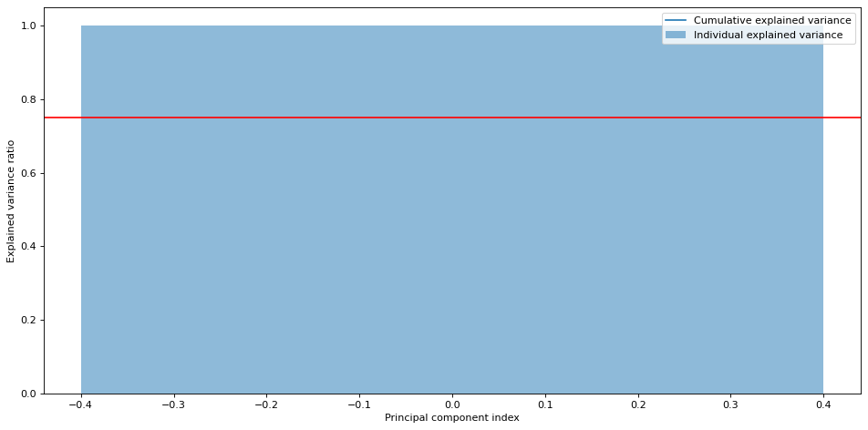

```python
lda = LDA()#primero lo hago sin fijar el número de componentes para visualizar la varianza

lda.fit(X_train_scaled[selected_feat], y_train)
X_train_lda = lda.transform(X_train_scaled[selected_feat])
X_test_lda = lda.transform(X_test_scaled[selected_feat])
exp_var_lda = lda.explained_variance_ratio_

cum_sum_eigenvalues = np.cumsum(exp_var_lda)

threshold = 0.75
plt.figure(figsize=(12, 6), dpi=80)
plt.bar(range(0,len(exp_var_lda)), exp_var_lda, alpha=0.5, align='center', label='Individual explained variance')
plt.step(range(0,len(cum_sum_eigenvalues)), cum_sum_eigenvalues, where='mid',label='Cumulative explained variance')
plt.axhline(y=threshold, color='r', linestyle='-')

plt.ylabel('Explained variance ratio')
plt.xlabel('Principal component index')
plt.legend(loc='best')
plt.tight_layout()
plt.show()
```

```python
cum_sum_eigenvalues
```

```
array([1.])
```

```python
lda = LDA(solver='svd', n_components=1)#primero lo hago sin fijar el número de componentes para visualizar la varianza

lda.fit(X_train_scaled[selected_feat], y_train)
X_train_lda = lda.transform(X_train_scaled[selected_feat])
X_test_lda = lda.transform(X_test_scaled[selected_feat])
```

```python
x_test_lda = pd.DataFrame(X_test_lda, index=X_test_scaled.index, columns = ['LDA_1'])
x_train_lda = pd.DataFrame(X_train_lda, index=X_train_scaled.index, columns = ['LDA_1'])
```

```python
clf = GradientBoostingClassifier(
              learning_rate=0.1,  max_depth=12,
              min_weight_fraction_leaf=0.02, n_estimators=130,
              random_state=2408,
              verbose=1)# n_estimators poner al menos 150, yo he puesto 2 para que ejecute rapido
clf.fit(X_train_lda,y_train)
# feature_importance = clf.feature_importances_
# # make importances relative to max importance
# feature_importance = 100.0 * (feature_importance / feature_importance.max())
# sorted_idx = np.argsort(feature_importance)
# pos = np.arange(sorted_idx.shape[0]) + .5
# # plt.subplot(1, 2, 2)
# plt.figure(figsize=(12, 20))
# plt.barh(pos, feature_importance[sorted_idx], align='center')
# plt.yticks(pos, X_train_lda.keys()[sorted_idx])
# plt.xlabel('Relative Importance')
# plt.title('Variable Importance')
# plt.show()
```

```
      Iter       Train Loss   Remaining Time
         1           1.0299           51.32s
         2           1.0127           50.61s
         3           0.9989           50.57s
         4           0.9878           50.34s
         5           0.9788           49.82s
         6           0.9714           49.52s
         7           0.9653           49.01s
         8           0.9602           49.06s
         9           0.9561           48.93s
        10           0.9526           48.60s
        20           0.9384           45.69s
        30           0.9362           42.13s
        40           0.9357           39.71s
        50           0.9356           38.00s
        60           0.9355           36.21s
        70           0.9355           32.78s
        80           0.9355           28.53s
        90           0.9354           23.63s
       100           0.9354           18.21s
```

```
GradientBoostingClassifier(max_depth=12, min_weight_fraction_leaf=0.02,
                           n_estimators=130, random_state=2408, verbose=1)
```

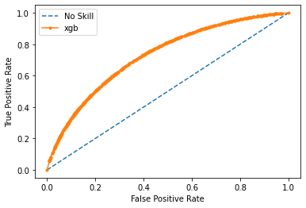

```
AUC: 0.729
```

```python
pred_test = clf.predict_proba(X_test_lda)
pred_train = clf.predict_proba(X_train_lda)
# keep probabilities for the positive outcome only
yhat_train = pred_train[:, 1]
# calculate roc curves
fpr, tpr, thresholds = metrics.roc_curve(y_train, yhat_train)
# plot the roc curve for the model
plt.plot([0,1], [0,1], linestyle='--', label='No Skill')
plt.plot(fpr, tpr, marker='.', label='xgb')
# axis labels
plt.xlabel('False Positive Rate')
plt.ylabel('True Positive Rate')
plt.legend()
# show the plot
plt.show()
# calculate AUC
auc = metrics.roc_auc_score(y_train, yhat_train)
print('AUC: %.3f' % auc)
```